# GDP and Life Expectancy Data Analysis

Shruti Grover

```r
library(tidyverse)
library(gapminder)
library(car)
library(gridExtra)
```

**Q1. Objective : To assess the normality of Life Expectancy in the Americas in the year 2007.**

1. First, we will use a histogram and a qqplot to understand the distribution of data -

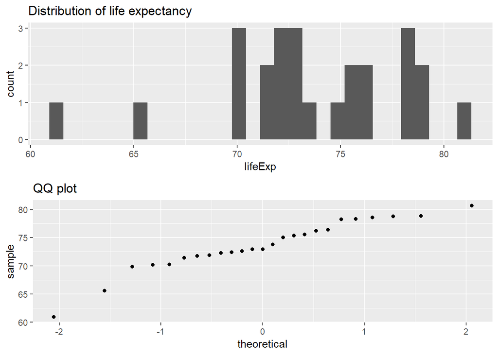

```r
gp <- gapminder %>%
  filter(continent=="Americas" & year=="2007")
g1 <- ggplot(subset(gapminder, continent=="Americas" & year=="2007"))
grid.arrange(g1 + geom_histogram(aes(x= lifeExp), bins = 30)+
               ggtitle("Distribution of life expectancy"), g1 + stat_qq(aes(sample = lifeExp))+ggtitle("QQ plot"))
```

From the above plots it can be observed that the distribution is nearly normal with a bit of negative skewness, which is also evident by the qqplot.

2. Next, we will use the Shapiro-Wilk test-

```r
shapiro.test(gp$lifeExp)
```

```
##
##  Shapiro-Wilk normality test
##
## data:  gp$lifeExp
## W = 0.93431, p-value = 0.1093
```

From the above output, the p-value > 0.05 implies that the distribution of the data is not significantly different from normal distribution. In other words, we can assume normality.

**Q2. Objective : To find if there are ‘population’ outliers when comparing Asian countries to European countries in 1952.**

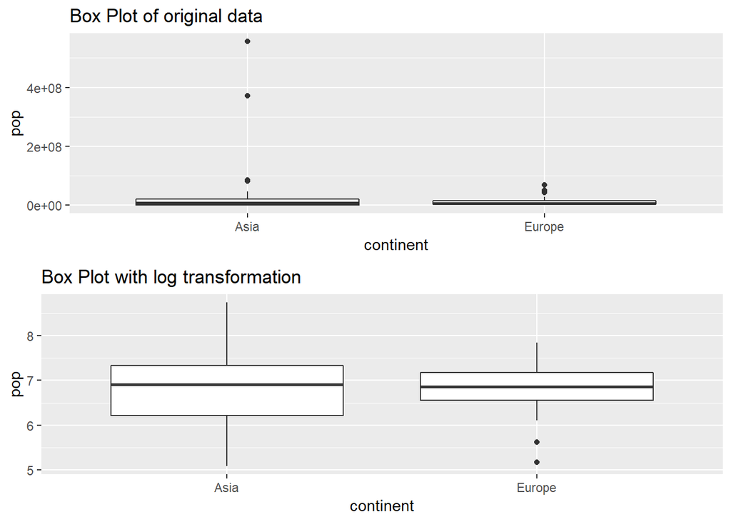

```r
gp2 <- gapminder %>%
  filter((continent=="Asia" | continent == "Europe") & year == "1952")
g2 <- ggplot(data = gp2, aes(x=continent,y=pop))
grid.arrange(g2+geom_boxplot() + ggtitle("Box Plot of original data"), g2+geom_boxplot(aes(x = continent, y = log10(pop))) + ggtitle("Box Plot with log transformation"))
```

From the above plots it can be observed that both continents “Asia” and “Europe” have outliers. Below are few of the common ways to handle outliers -

1. **Remove outliers** : This method is used when the outlier values are not possible/realistic. However, in this case removing outliers is not an appropriate option as the population values are legitimate.
2. **Transform data** : The values can be tranformed to log, square root, percentile. These are just few of the methods for transormation, there can be other possible tranformations too.
3. **Change score** : This means to change the outlier value to +1 of the next highest value or to 3 standard deviation above mean. However, changing score is not considered a good option as the outlier value gets changed.

**Method used for this comparison** - In our case we have used log tranformation to handle data and from the above plot it can be observed that this method has handled the outliers really well which results in no outliers for Asia and a couple for Europe.

As population of a continent is an important and legitimate value, removing and changing the values of outliers is not a good option and leads to improper analysis.

**Q3. Objective:** 1. To conduct the appropriate statistical test, demonstrate the underlying assumptions, plot the results, and briefly report the results in a publishable format. 2. To answer a research question.

Below is the research question we will be answering:

**“Is life expectancy greater in Europe compared to Asia in 2007?”**

I. Statistical tests and Assumptions :

An independent t-test will be used to compare life expectancy of Europe and Asia in year 2007. The Kolmogorov-Smirnov test will be used to test for normality, and Levene’s test for homogeneity of variance. Significance will be set at α < 0.05.

1. Normality

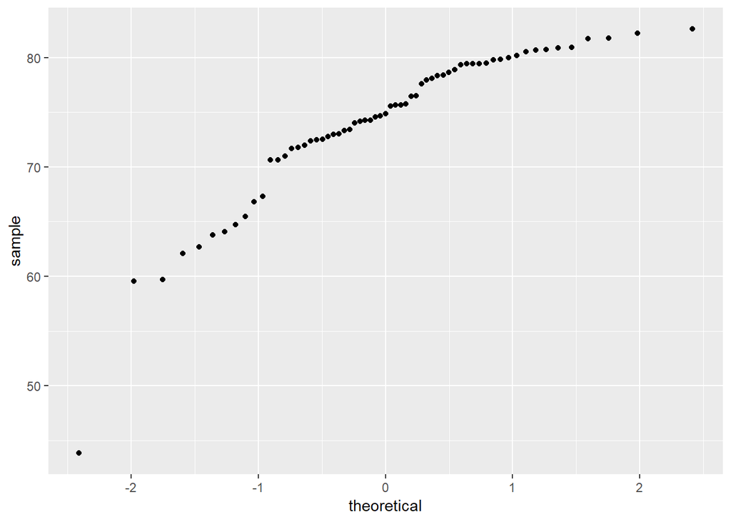

```r
gp3 <- gapminder %>%
  filter((continent == "Asia" | continent == "Europe") & year == "2007")
ggplot(dat=gp3) +
  stat_qq(aes(sample = lifeExp))
```

```r
ks.test(x=gp3$lifeExp, y="pnorm", mean=mean(gp3$lifeExp), sd=sd(gp3$lifeExp))
```

```
##
##  One-sample Kolmogorov-Smirnov test
##
## data:  gp3$lifeExp
## D = 0.14712, p-value = 0.1181
## alternative hypothesis: two-sided
```

From the above output, the p-value > 0.05 implies that the distribution of the data is not significantly different from normal distribution. In other words, we can assume the normality.

2. Homogeneity of variance :

```r
leveneTest(lifeExp~continent, data = gp3)
```

```
## Levene's Test for Homogeneity of Variance (center = median)
##       Df F value   Pr(>F)
## group  1  9.0017 0.003902 **
##       61
## ---
## Signif. codes:  0 '***' 0.001 '**' 0.01 '*' 0.05 '.' 0.1 ' ' 1
```

The Levene’s test uses an F-test to test the null hypothesis that the variance is equal across groups. A p value less than .05 in this case indicates a violation of the assumption, i.e, the variance of life expectancy is unequal among the two countries, Asia and Europe. However, we can handle the violation of this assumption in R by the options to either assume or not assume homogeneity of variance.

3. Interval Data : Life Expectancy is an interval data as it consists of continuous values. Hence, this assumption is satisfied.

```r
gp3$lifeExp
```

```
##  [1] 43.828 76.423 79.829 75.635 64.062 79.441 74.852 73.005 59.723 72.961
## [11] 75.748 76.486 78.332 79.313 80.657 79.406 79.483 82.208 73.338 81.757
## [21] 64.698 70.650 70.964 59.545 78.885 80.745 80.546 82.603 72.535 67.297
## [31] 78.623 77.588 71.993 74.241 66.803 74.543 62.069 63.785 79.762 80.196
## [41] 75.640 65.483 71.688 75.563 78.098 72.476 72.777 74.002 79.972 74.663
## [51] 77.926 80.941 72.396 80.884 81.701 74.143 78.400 70.616 71.777 79.425
## [61] 74.249 73.422 62.698
```

4. Independence : The life expectancy of people in Europe is independent of that of Asia. Hence, this assumption is satisfied.

Now, after testing the assumptions we can proceed with the independent t-test to check if the life expectancy greater in Europe compared to Asia -

```r
t.test(formula = gp3$lifeExp ~ gp3$continent,
       data = gp3,
       alternative = "two.sided",
       var.equal = TRUE,
       paired = FALSE)
```

```
##
##  Two Sample t-test
##
## data:  gp3$lifeExp by gp3$continent
## t = -4.4802, df = 61, p-value = 3.34e-05
## alternative hypothesis: true difference in means is not equal to 0
## 95 percent confidence interval:
##  -10.008747  -3.831484
## sample estimates:
##   mean in group Asia mean in group Europe
##             70.72848             77.64860
```

For a t-test, the null hypothesis is that the means for both groups are equal, versus the alternative hypothesis that the means are not equal. As the p-value above is small (<0.05), the null hypothesis can be rejected and alternative hypothesis is true, i.e, the means of life expectancy in Asia and Europe are not equal.

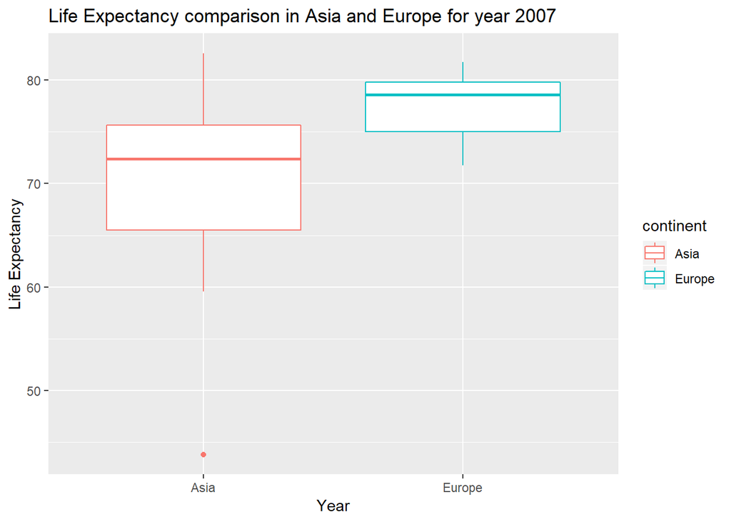

```r
ggplot(dat = gp3, aes(x = continent, y = lifeExp, color = continent)) +
  geom_boxplot()+
  ggtitle("Life Expectancy comparison in Asia and Europe for year 2007") +
  xlab("Year") +
  ylab("Life Expectancy")
```

**Results:** From the above tests, it was found that the Life Expectancy in Asia and Europe (D=0.14712; p >0.05) was normal. However, life expectancy in Asia and Europe had unequal variance (F=9.0017 ; p=0.003902). This was handled by assuming homogenity of variance while performing the t-test. The independent t-test shows that the mean of life expectancy in Asia and Europe are unequal and life expectancy Asia is smaller than in Europe(70.72848 v/s 77.64860, P=3.34e-05) in year 2007.

An independent t-test will be used to analyze difference between GDP in year 1987 and 1997. The Kolmogorov-Smirnov test will be used to test for normality, and Levene’s test for homogeneity of variance. If data is found to be non-normal, data will be log-transformed. Significance will be set at α < 0.05.

```r
gdp <- gapminder %>%
  filter(continent == "Asia" & (year == "1987" | year == "1997"))
summary(gdp)
```

```
##              country      continent       year         lifeExp
##  Afghanistan     : 2   Africa  : 0   Min.   :1987   Min.   :40.82
##  Bahrain         : 2   Americas: 0   1st Qu.:1987   1st Qu.:60.69
##  Bangladesh      : 2   Asia    :66   Median :1992   Median :67.73
##  Cambodia        : 2   Europe  : 0   Mean   :1992   Mean   :66.44
##  China           : 2   Oceania : 0   3rd Qu.:1997   3rd Qu.:71.42
##  Hong Kong, China: 2                 Max.   :1997   Max.   :80.69
##  (Other)         :54
##       pop              gdpPercap
##  Min.   :4.546e+05   Min.   :  385
##  1st Qu.:4.778e+06   1st Qu.: 1716
##  Median :1.888e+07   Median : 3830
##  Mean   :9.477e+07   Mean   : 8721
##  3rd Qu.:6.017e+07   3rd Qu.:16840
##  Max.   :1.230e+09   Max.   :40301
##
```

Testing Assumptions : 1. Normality 2. Homogeneity of Variance 3. Interval Data 4. Independence

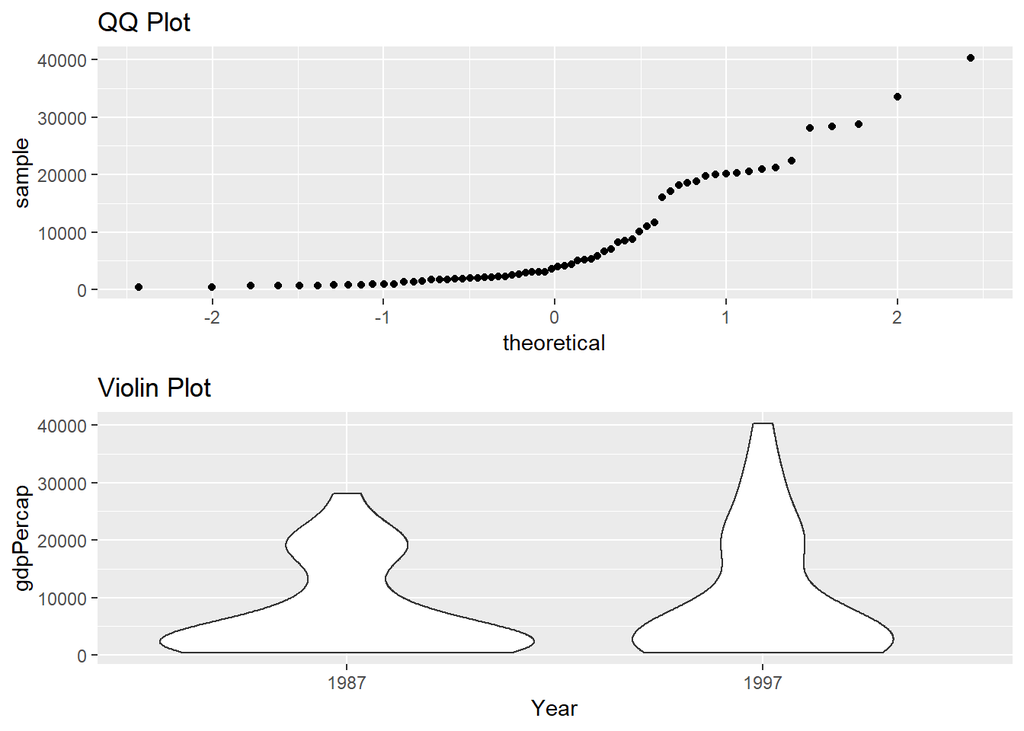

```r
#1. Normality
gg <- ggplot(dat=gdp)
grid.arrange(gg+stat_qq(aes(sample = gdpPercap))+ggtitle("QQ Plot"), gg +  geom_violin(aes(x = factor(year), y = gdpPercap))+xlab("Year")+ggtitle("Violin Plot"))
```

```r
ks.test(x=gdp$gdpPercap, y="pnorm", mean=mean(gdp$gdpPercap), sd=sd(gdp$gdpPercap))
```

```
##
##  One-sample Kolmogorov-Smirnov test
##
## data:  gdp$gdpPercap
## D = 0.22578, p-value = 0.001943
## alternative hypothesis: two-sided
```

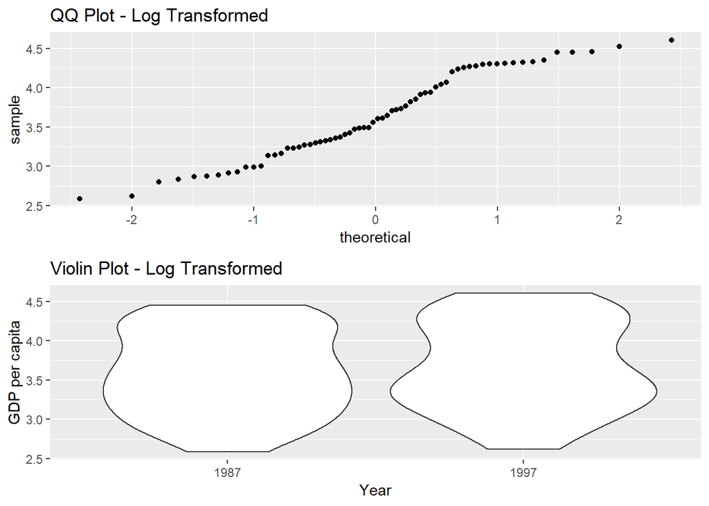

```r
#log transformation to make the data normal
gdp <- gdp %>%
  mutate(gdp_log = log10(gdpPercap))

gg2 <- ggplot(dat=gdp)
grid.arrange(gg2+stat_qq(aes(sample = gdp_log))+ggtitle("QQ Plot - Log Transformed"), gg2 +  geom_violin(aes(x = factor(year), y = gdp_log))+xlab("Year")+ylab("GDP per capita")+ggtitle("Violin Plot - Log Transformed"))
```

```r
ks.test(x=gdp$gdp_log, y="pnorm", mean=mean(gdp$gdp_log), sd=sd(gdp$gdp_log))
```

```
##
##  One-sample Kolmogorov-Smirnov test
##
## data:  gdp$gdp_log
## D = 0.12088, p-value = 0.2675
## alternative hypothesis: two-sided
```

```r
#2. Homogenity of Variance
leveneTest(gdp_log~factor(year), data = gdp)
```

```
## Levene's Test for Homogeneity of Variance (center = median)
##       Df F value Pr(>F)
## group  1  0.0941 0.7601
##       64
```

```r
#3. Interval Data - gdpPercap is continuous data. Hence, meeting the assumption
#4. Independence -  The GDP of continent Asia is independent of that of Asia.
```

Above, we can see the violin and QQ plots with and without log transformation. Also, the results of the KS test shows that before log transormation, p < 0.05 that means data is non normal. However, after the tranformation p=0.2675 > 0.05, hence, satisfying normalcy.

Statistical Test -

```r
t.test(formula= gdp_log ~ year,
       data = gdp,
       alternative="two.sided",
       var.equal=TRUE,
       paired=FALSE)
```

```
##
##  Two Sample t-test
##
## data:  gdp_log by year
## t = -0.6018, df = 64, p-value = 0.5494
## alternative hypothesis: true difference in means is not equal to 0
## 95 percent confidence interval:
##  -0.3552153  0.1907473
## sample estimates:
## mean in group 1987 mean in group 1997
##           3.594727           3.676961
```

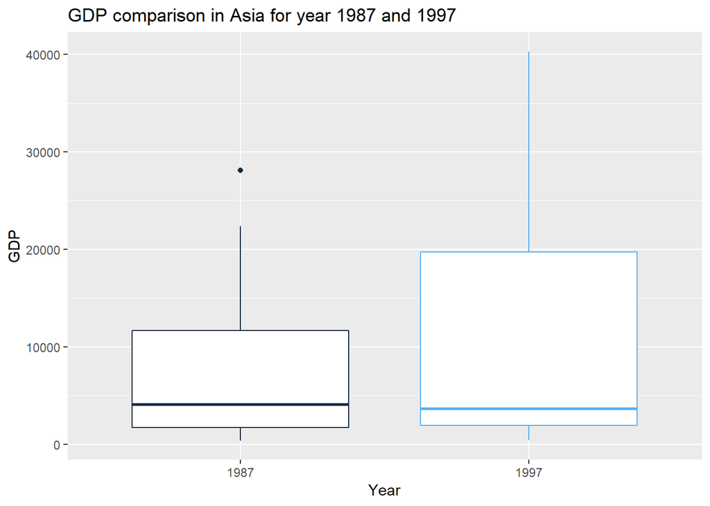

```r
ggplot(data=gdp, aes(x = factor(year), y = gdpPercap, colour = year)) +
  geom_boxplot()+
  ggtitle("GDP comparison in Asia for year 1987 and 1997 ") +
  xlab("Year") +
  ylab("GDP") +
  theme(legend.position = "none")
```

**Results**: From the above tests, it was found that the GDP per Capita for the year 1987 and 1997 (D=0.22578; p <0.05) was non-normal. Therefore, log-transformation was done. Using the log-transformed data, GDP had equal variance (F=0.0941; p=0.7601). The independent t-test shows that the mean of GDP per capita in 1987 is almost equal to that of 1997 where GDP in 1987 is slightly smaller than GDP in 1997 (3.594727 v/s 3.676961, P=0.5494)